# Praca domowa 3

Maciej Andrzejewski

# Wizualizacja źródłowa

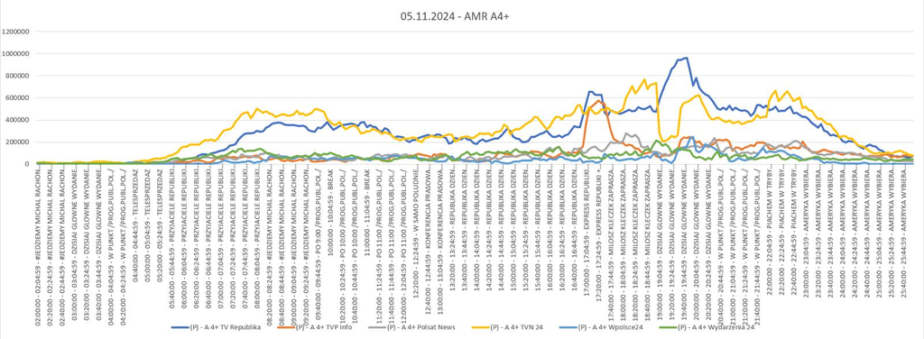

Źródło: [Post Tomasza Sakiewicza na platformie X](https://x.com/TomaszSakiewicz/status/1854086331669913754)  
Data publikacji: 10:00 AM · 6 lis 2024

Celem wizualizacji były pokazanie odniesionego przez TV Republikę sukcesu oglądalnościowego w czasie wieczoru wyborczego 05.11.2024 (wybory prezydenckie w USA).

# Elementy do poprawy

Głównym problemem tego wykresu jest mała czytelność.

### Co należałoby poprawić:

- oznaczenia na osi OY - są to liczby zapisane przy pomocy nieoddzielonej w żaden sposób dużej liczby zer, co utrudnia dokładne odczytanie rzędu wielkości tych liczb (zwłaszcza podczas wyświetlania tego wykresu w telewizji, gdzie nie da się przybliżyć obrazu);
- oznaczenia na osi OX - reprezentują mało czytelne przedziały godzinowe, a dodatkowo zawierają zbędne (zmniejszające czytelność) tytuły programów, które dotyczą wyłącznie jednej stacji; pojawia się także enigmatyczna godzina 25:00:00;
- legenda - została stworzona zbyt mała, dodatkowo występują w niej zbędne informacje (zamiast samych nazw stacji), a także nachodzą na nią znaczniki z osi OX;
- tytuł - osadzony poza kontekstem przeciętnemu odbiorcy nie mówi nic o treści wizualizacji;
- wyróżnienie fragmentu, na którym nam zależy - tego po prostu brakuje.

# Nowa wizualizacja

Poniżej znajduje się nowa wersja wykresu (oraz odpowiedni **kod**), stworzona za pomocą `ggplot2` oraz danych podobnych do pierwotnych (w kluczowych fragmentach odczytanych z wykresu, wpp. wygenerowanych pseudolosowo).

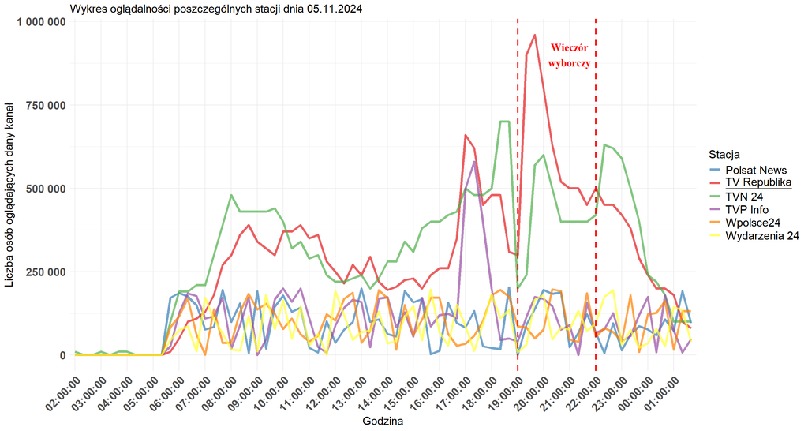

```r
df_long <- df %>% mutate(X = factor(X, levels = X)) %>%
  tidyr::pivot_longer(cols = 2:7) %>%
  rename(time = X, station = name, count = value)

ggplot(df_long,
       aes(time, count, group = station, color = station)) +
  geom_line(linewidth = 1.5, alpha = 0.7) +
  labs(title = "Wykres oglądalności poszczególnych stacji dnia 05.11.2024",
       y = "Liczba osób oglądających dany kanał",
       x = "Godzina",
       color = "Stacja") +
  theme_minimal() +
  theme(axis.text.x = element_text(size = 15, angle = 45, hjust = 1, face = "bold"),
        axis.text.y = element_text(size = 15, face = "bold"),
        plot.title = element_text(size = 15),
        legend.text = element_text(size = 15),
        legend.title = element_text(size = 15),
        axis.title = element_text(size = 15)
        ) +
  scale_x_discrete(breaks = unique(df_long$time)[
    seq(1, length(df_long$time), by = 3)]) +
  scale_color_manual(values = brewer.pal(6,"Set1")[c(2,1,3:6)],
                     labels = c("Polsat News", expression(underline("TV Republika")), "TVN 24", "TVP Info", "Wpolsce24", "Wydarzenia 24")) +
  scale_y_continuous(labels = scales::label_number(big.mark = " ")) +
  geom_vline(xintercept = 52, color = "red", linetype = "dashed", linewidth = 1) +
  geom_vline(xintercept = 61, color = "red", linetype = "dashed", linewidth = 1) +
  annotate("text", x = 58, y = 900000,
           label = "Wieczór\nwyborczy",
           color = "red",
           size = 5,
           fontface = "bold",
           family = "serif",
           hjust = 0.5, vjust = 0.5)
```

# Uzasadnienie poprawy

Nowa wersja wykresu jest lepsza od oryginału, ponieważ:

- liczby na osi OY są bardziej czytelne;
- liczba znaczników na osi OX jest mniejsza i zawiera tylko godzinę (kluczową informację);
- tytuł oraz legenda są przystępniejsze w odbiorze;
- fragment wykresu, który nas interesuje, został wyraźnie zaznaczony.